# Data Exploration and Visualization of Seattle Housing Permits

Daniel Cavazos (cavazd@uw.edu), Townson Cocke (tbsc@uw.edu)

10/27/2021 (MM/DD/YYYY)

# Dataset Introduction

To analyze the housing permits in Seattle we looked at data provided by the City of Seattle. This data begins in 2017 and is current as of October 14, 2021. In the dataset, there are 22 variables and 34860 observations. The variable names are: PermitNum, PermitClass, PermitClassMapped, PermitTypeMapped, PermitTypeDesc, Description, HousingUnits, HousingUnitsRemoved, HousingUnitsAdded, EstProjectCost, IssuedDate, StatusCurrent, OriginalAddress1, OriginalCity, OriginalState, OriginalZip, ContractorCompanyName, IssuedYear, IssuedMth, CouncilDistrict, CommunityReportingArea, NeighborhoodDistrict.

# NA Values

To better understand the data we’re working with, we wanted to look at the number of NA values present. Overall there are 95965 NA values which accounts for 12.5130392% of the data.

For a closer look at the number of NA values, we looked at the number of NA values by variable.

|  | PermitNum | PermitClass | PermitClassMapped | PermitTypeMapped | PermitTypeDesc | Description | HousingUnits | HousingUnitsRemoved | HousingUnitsAdded | EstProjectCost | IssuedDate | StatusCurrent | OriginalAddress1 | OriginalCity | OriginalState | OriginalZip | ContractorCompanyName | IssuedYear | IssuedMth | CouncilDistrict | CommunityReportingArea | NeighborhoodDistrict |
| --- | --- | --- | --- | --- | --- | --- | --- | --- | --- | --- | --- | --- | --- | --- | --- | --- | --- | --- | --- | --- | --- | --- |
| Number of NAs | 0 | 0 | 0 | 0 | 1287 | 1 | 22500 | 15613 | 15613 | 1603 | 0 | 0 | 0 | 2120 | 2225 | 2803 | 31923 | 0 | 0 | 93 | 92 | 92 |

The values we care about the most are those with over 10 thousand NA values which are the following.

|  | HousingUnits | HousingUnitsRemoved | HousingUnitsAdded | ContractorCompanyName |
| --- | --- | --- | --- | --- |
| Number of NAs | 22500 | 15613 | 15613 | 31923 |

Knowing that these variables have a lot of NA values allows us to make more informed decisions about our visualizations.

# Estimated Project Cost From 2017 to 2021 by Month

When we first looked at the available variables in the dataset, our first thought was to look at how the project cost changed over time. To do so, we created the following visualization.

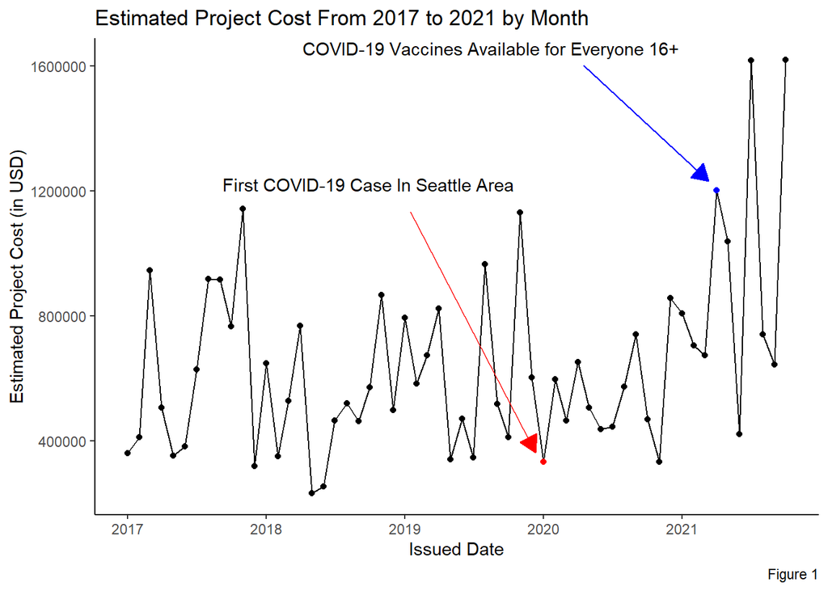

To create this visualization, we took the mean estimated project cost grouped by year and month. There appears to be normal seasonal fluctuation in the data until January 2020. Here it appears the project costs lower for about a year. This date correlates with when the first COVID-19 case appeared in the Seattle area. The estimated project cost then seems to have slowly increased as more people returned to work and spiked considerably after COVID-19 vaccines became available for everyone aged 16+ in Seattle (April, 2021). While not drastic, it appears COVID-19 correlated to some of the variation in the estimated project of housing permits.

# Estimated Project Cost by Housing Units Added

Another question we had was if the number of housing units added to a project had an impact on the estimated project cost. To further analyze this question, we decided to use a scatterplot of the data. One issue that was presented, however, is the number of NA values present in HousingUnitsAdded variable. There are 15,613 NA values present in this variable. We decided to then operate under this assumption: due to there being observations of 0 in the HousingUnitsAdded variable and the existence of various other forms of permit types, a prevalence of NA values will not affect our analysis.

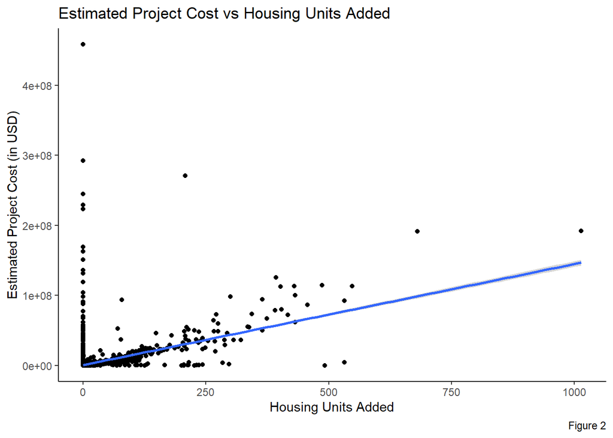

Looking at this visualization, we see there are a large number of observations with 0 housing units added. Besides these points, there appears to be a strong linear correlation. When looking at observations where 0 housing units were added there was no variable with an overwhelming number of these particular observations. This tells us there is no variable which we could reasonably exclude to justify this linear correlation. For summary statistics, we see that when 0 housing units are added, we expect the estimated project cost to be 510,439.4 USD. Additionally, for every 1 housing unit added, we expect the estimated project cost to increase by 144,413.9 USD. And, while these coefficients are statistically significant (p-values < 0.001), the R-squared value is only 0.2006939 meaning about 20% of the variation in the estimated project cost can be explained by the variation in the housing units added. This likely means there is some association between housing units added and the estimated project cost, however, there are other variables (whether in the dataset or not) which more strongly correlate with the project cost. Additionally, while it is possible the number of housing units added slightly causes an increase in the estimated project cost, it is more likely other variables hold more weight.

(Note: the type of regression model used was OLS).

# Housing Units Added by Zipcode

Another question we wanted to attempt to answer was how, if at all, housing units added varied by ZIP code. To represent this, we displayed the number of housing units over a map of the Seattle area. To note, we operated under the same assumption we mentioned in the previous section.

[interactive chart not shown]

From this visualization, we can see that the majority of units added were centralized around 4 main places. These areas are: Downtown Seattle, Lake Union, the University District, and Seatac. These areas are associated with the most impactful areas around Seattle. Besides these main areas, most of the other ZIP codes received little to no housing units added. This visualization suggests that ZIP code does have an association with the number of housing units added in a permit. There are many reasons why this could happen: industrial vs residential, more rich areas, old redlining issues continuing into today’s marketplace. Further research would have to be done with a dataset with different variables.

# Number of Permits From 2017 to 2021

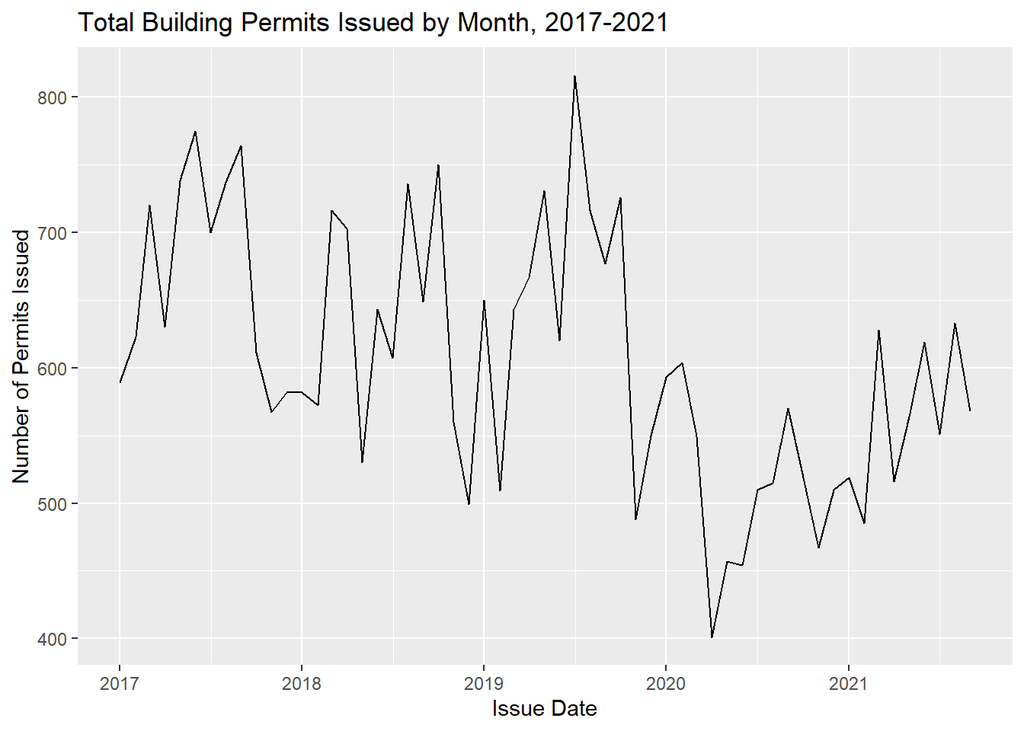

# Average Expense by Seattle Council District

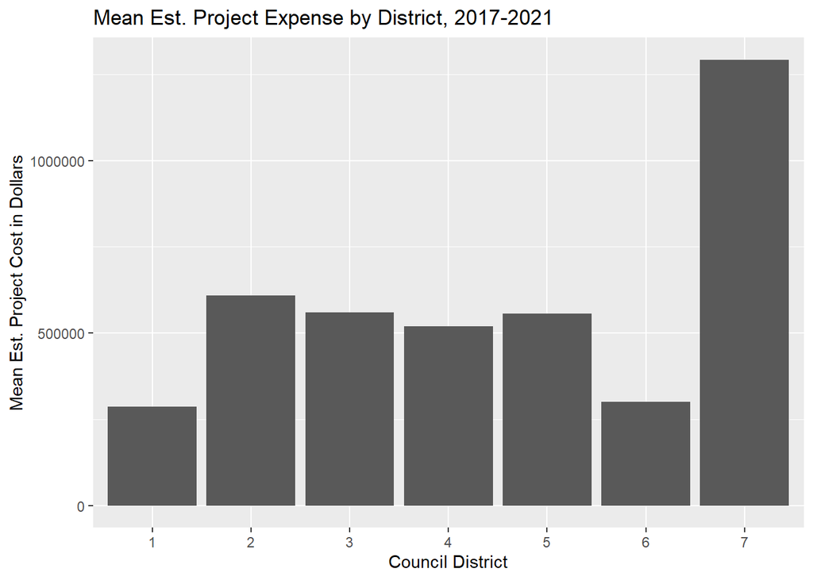

# Types of Building Permits by Seattle Council Districts

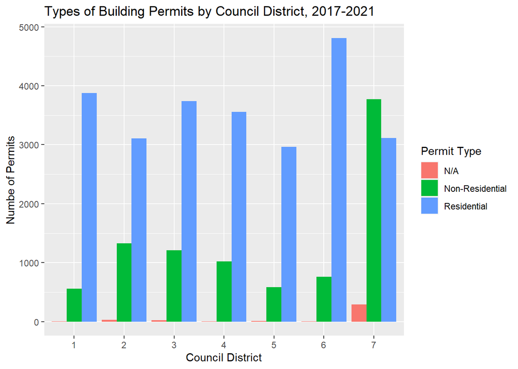

For this chart, we were interested in exploring how much and what type of construction is undertaken in different parts of Seattle in the past four years. Does the commercial or residential character of each of the seven districts show up in the building permit data? We find that, for example, in District 7, which encompasses Seattle’s downtown area, there were indeed more non-residential (i.e. most likely commercial projects such as office buildings, warehouses, etc.) building permits issued than residential ones. Perplexingly, however, District 1 – which includes West Seattle and the Industrial District – had more residential permits issued from 2017 to 2021. In District 2, a downtown area, there is a higher ratio of non-residential to residential construction than in other districts, although here too, more residential permits were issued overall. Overall, then, we see that there are many more residential than non-residential building permits issued in the city, which probably reflects the fact that for example, every time a homeowner wants to renovate her home, she has to be issued a building permit; meanwhile, only one building permit is issued for much bigger commercial/non-residential projects. This suggests that simply looking at the building permit type as the “unit of construction” may be misleading on its own. A better data point to look at might have been units of housing or (for commercial projects) square footage, however, the former in this data set had too many NA values to be useful; square footage was not provided.

Note: the small amount of N/A data here reflects building permits for which the permit type (either residential or non-residential) was not listed.

# Code Appendix

```r
# ----- imports -----
library(tidyverse)
library(kableExtra)
library(leaflet)
library(zipcodeR)
library(htmltools)


# read in data
housing_df <- read.csv("Building_Permits_Clean.csv")


# find last date in the dataset
last_date <- housing_df %>%
  select(IssuedDate) %>%
  mutate(IssuedDate = as.Date(IssuedDate, "%m/%d/%y")) %>%
  arrange(desc(IssuedDate)) %>%
  head(1) %>%
  pull()

# ----- number of NA values -----

# make matrix to show off the number of NAs per column
numNAs <- matrix(data = colSums(is.na(housing_df)),
                 ncol = ncol(housing_df),
                 nrow = 1,
                 dimnames = list(c("Number of NAs"),
                                 colnames(housing_df))
                 )

# make matrix to show off the columns where NAs > 10000
NAs_over_10k <- data.frame(numNAs) %>%
  pivot_longer(
    cols = colnames(housing_df),
    names_to = "ColNames",
    values_to = "number_NAs"
  ) %>%
  filter(number_NAs >= 10000) %>%
  pivot_wider(
    names_from = ColNames,
    values_from = number_NAs
  ) %>%
  as.matrix()

# change row name
rownames(NAs_over_10k) <- "Number of NAs"

# display code for the number of NA values
scroll_box(kable_styling(kable(numNAs)), width = "910px", height = "130px")

# display code for the columns with NA values over 10k
kable_styling(kable(NAs_over_10k))

# ----- time vs estimated cost -----

# make the issued date a date type. select only issued date and the estimated
# project cost
cost_vs_date_df <- housing_df %>%
  group_by(IssuedYear, IssuedMth) %>%
  summarise(EstProjectCost = mean(EstProjectCost, na.rm = TRUE)) %>%
  mutate(IssuedDay = 1) %>%
  unite(IssuedDate, c(IssuedYear, IssuedMth, IssuedDay), sep = "/") %>%
  mutate(IssuedDate = as.Date(IssuedDate, "%Y/%m/%d"))

# row of the first covid case in seattle
first_case_covid_month <- cost_vs_date_df %>%
  filter(IssuedDate == "2020-01-01")

# row when vaccines were available for everyone 16+
vax_for_16_up_month <- cost_vs_date_df %>%
  filter(IssuedDate == "2021-04-01")

# graph showing project cost vs time.
cost_over_time_plt <- ggplot(data = cost_vs_date_df,
                             aes(x = IssuedDate, y = EstProjectCost, group=1)) +
  geom_line() + # add line
  geom_point() + # add dots
  geom_point(data = first_case_covid_month, color = "red") + # add covid dot
  geom_point(data = vax_for_16_up_month, color = "blue") + # add vax dot
  # add explanatory text for the covid dot
  geom_text(data = first_case_covid_month,
            label = "First COVID-19 Case In Seattle Area",
            hjust = 1.1,
            vjust = -20) +
  # add explanatory text for the vax dot
  geom_text(data = vax_for_16_up_month,
            label = "COVID-19 Vaccines Available for Everyone 16+",
            hjust = 1.1,
            vjust = -10) +
  # add arrow for covid dot
  geom_segment(aes(x = first_case_covid_month$IssuedDate - 350,
                   y = first_case_covid_month$EstProjectCost + 800000,
                   xend = first_case_covid_month$IssuedDate - 20,
                   yend = first_case_covid_month$EstProjectCost + 30000),
               arrow = arrow(length = unit(0.4, "cm"),
                             type = "closed"),
               color = "red") +
  # add arrow for vax dot
  geom_segment(aes(x = vax_for_16_up_month$IssuedDate - 350,
                   y = vax_for_16_up_month$EstProjectCost + 400000,
                   xend = vax_for_16_up_month$IssuedDate - 20,
                   yend = vax_for_16_up_month$EstProjectCost + 30000),
               arrow = arrow(length = unit(0.4, "cm"),
                             type = "closed"),
               color = "blue") +
  # styling
  xlab("Issued Date") +
  ylab("Estimated Project Cost (in USD)") +
  labs(title = "Estimated Project Cost From 2017 to 2021 by Month",
       caption = "Figure 1") +
  theme_classic()

plot(cost_over_time_plt)

# ----- housing units added vs estprojectcost

# select housing and project cost and exclude NA values
cost_vs_housing_add_df <- housing_df %>%
  select(EstProjectCost, HousingUnitsAdded) %>%
  na.omit()

# create scatter plot with project cost vs units added
cost_vs_housing_add_plt <- ggplot(data = cost_vs_housing_add_df,
                                  aes(x = HousingUnitsAdded,
                                      y = EstProjectCost)) +
  geom_point() + # add dots
  geom_smooth(method = "lm", formula = "y ~ x") + # add linear regression line
  # styling
  theme_classic() +
  xlab("Housing Units Added") +
  ylab("Estimated Project Cost (in USD)") +
  labs(title = "Estimated Project Cost vs Housing Units Added",
       caption = "Figure 2")

# do ols linear regression
cost_vs_housing_model <- lm(data = cost_vs_housing_add_df,
                            EstProjectCost ~ HousingUnitsAdded)

# find summary statistics for model
cost_vs_housing_sum <- summary(cost_vs_housing_model)

# display plot
plot(cost_vs_housing_add_plt)

# ----- housing units added by ZIP code -----

# use existing zipcode dataset to find lat and lng vals by zipcode
zips_df <- zip_code_db %>%
  mutate(zipcode = as.integer(zipcode)) %>%
  select(zipcode, lat, lng)

# select housing units and zip codes, omit NAs, group by zip and get total units
# added, join the zipcode dataset with the modified housing dataset to add
# lat lng values.
housing_map_df <- housing_df %>%
  select(HousingUnitsAdded, OriginalZip) %>%
  na.omit() %>%
  group_by(OriginalZip) %>%
  summarise(total_units_added = sum(HousingUnitsAdded)) %>%
  filter(OriginalZip > 0) %>%
  left_join(y = zips_df,
            by = c("OriginalZip" = "zipcode"))

# style the title:
# code from prusswan on
# https://stackoverflow.com/questions/49072510/r-add-title-to-leaflet-map
tag.map.title <- tags$style(HTML("
  .leaflet-control.map-title {
    transform: translate(30%,-250%);
    text-align: center;
    padding-left: 10px;
    padding-right: 10px;
    background: rgba(255,255,255,0.75);
    font-weight: bold;
    font-size: 18px;
    border: 2px solid #969696;
  }
"))

title <- tags$div(
  tag.map.title, HTML("Housing Units Added by ZIP Code in Seattle, WA")
)

# create map using leaflet
housing_map_plt <- housing_map_df %>%
  leaflet() %>%
  # add cool backgrounds
  addProviderTiles(providers$Esri.WorldImagery, group = "World Imagery") %>%
  addProviderTiles(providers$Stamen.TonerLite, group = "Toner Lite") %>%
  # make it possible to change layers
  addLayersControl(baseGroups = c("Toner Lite", "world Imagery")) %>%
  # add circles
  addCircleMarkers(lat = housing_map_df$lat,
             lng = housing_map_df$lng,
             # radius is scaled consistently
             # (+1 to show zips with 0 added houses)
             radius = ((housing_map_df$total_units_added /
                         mean(housing_map_df$total_units_added)) * 10 + 1),
             # add popup message
             popup = paste("ZIP Code: ",
                           housing_map_df$OriginalZip,
                           "<br>", "Units Added: ",
                           housing_map_df$total_units_added)) %>%
  addControl(title, position = "topleft", className = "map-title")

# display map
housing_map_plt


# ----- number of permits over time -----

#here we group the data by month and year in order to get counts of permits
# issued over time for the past 4 years.
permits_over_time <- housing_df %>%
  group_by(IssuedYear, IssuedMth) %>%
  summarize(count = n())%>%
  mutate(IssuedDay = 1) %>%
  unite(IssuedDate, c(IssuedYear, IssuedMth, IssuedDay), sep = "/") %>%
  mutate(IssuedDate = as.Date(IssuedDate, "%Y/%m/%d"))

#because we lack complete data for October 2021, we omit the month entirely
permits_over_time  <- filter(permits_over_time, IssuedDate != as.Date("2021-10-1"))

#plotting the permits over time data
permits_over_time_plot <- ggplot(data = permits_over_time, aes(x = IssuedDate, y = count, group = 1)) +
  geom_line() +
  xlab("Issue Date") +
  ylab("Number of Permits Issued") +
  labs(title = "Total Building Permits Issued by Month, 2017-2021")

permits_over_time_plot



# ----- mean expense by district -----

#grouping the data by council district and taking the mean est. project cost for each district.
expense_by_district <- housing_df %>%
  group_by(CouncilDistrict) %>%
  summarise(EstProjectCost = mean(EstProjectCost, na.rm = TRUE))

#Plotting the data. As before, we override the default tick marks. Also, since scientific notation doesn't make much sense here, we opt for numeric values (in dollars)
mean_expense_by_district <- ggplot(expense_by_district, aes(y = EstProjectCost, x = CouncilDistrict)) +
  geom_bar(position = "dodge", stat = "identity") +
  scale_x_discrete(name = "Council District", limits = c("1", "2", "3", "4", "5", "6", "7")) +
  ggtitle("Mean Est. Project Expense by District, 2017-2021") +
  ylab("Mean Est. Project Cost in Dollars") +
  scale_y_continuous(labels = function(x) format(x, scientific = FALSE))

mean_expense_by_district


# ----- types of building permits by council district -----
#getting counts of permit type, grouped by district and "permitclassmapped"
permit_classmapped_district <- housing_df %>%
  group_by(CouncilDistrict, PermitClassMapped) %>%
  summarize(count = n())

#Plotting using ggplot
#we give 3 arguments to aes for a multiple bar chart: fill, y (axis), and x (axis)
#we override the default x axes tick marks; replacing with 1:7, for each council district
#scale_fill_discrete: used to label the chart legend
permitclass_by_district <- ggplot(permit_classmapped_district, aes(fill = PermitClassMapped, y = count, x = CouncilDistrict)) +
  geom_bar(position = "dodge", stat = "identity") +
  scale_x_discrete(name = "Council District", limits = c("1", "2", "3", "4", "5", "6", "7")) +
  ggtitle("Types of Building Permits by Council District, 2017-2021") +
  ylab("Numbe of Permits") +
  scale_fill_discrete(name = "Permit Type")
#Printing out the plot
permitclass_by_district
```